###PSY 4960 Research Project Step F

Mitchell Lee & Connor Prok

Research Questions:

1. How does parents’ education status correlate with students’ final grades?

Hypothesis: There is a positive correlation between parents’ education status and students’ final grades.

2. Does number of alcoholic beverages consumed during the weekdays correlate with students grades?

Hypothesis: There is a negative correlation between number of alcoholic beverages consumed during the weekdays and students’ academic grades.

3. Does the number of hours studied, specifically quartile, have a statistical difference on final grades?

Hypothesis: There will be statistical differences in final grades between the students who study less the median hours studied, those who were at the median hours studied, and those who studied higher than the median hours studied. More study hours will correlate positively and cause higher test grades between the three groups.

###Data Cleaning Import data set.

```r
library(readr)
student_por <- read.csv("~/Desktop/Final Project/student-por.csv")
```

Load in necessary packages.

```r
library(jtools)
```

```r
library(ggplot2)
library(tidyverse)
```

Printed column names to better assess what variable is being used in analyses.

```r
colnames(student_por)
```

```
##  [1] "school"     "sex"        "age"        "address"    "famsize"
##  [6] "Pstatus"    "Medu"       "Fedu"       "Mjob"       "Fjob"
## [11] "reason"     "guardian"   "traveltime" "studytime"  "failures"
## [16] "schoolsup"  "famsup"     "paid"       "activities" "nursery"
## [21] "higher"     "internet"   "romantic"   "famrel"     "freetime"
## [26] "goout"      "Dalc"       "Walc"       "health"     "absences"
## [31] "G1"         "G2"         "G3"
```

Changed some levels of different variables to read demographic information more easily.

```r
student_por$address <- as.factor(student_por$address)
levels(student_por$address)
```

```
## [1] "R" "U"
```

```r
levels(student_por$address) <- c("Rural", "Urban")

student_por$Pstatus <- as.factor(student_por$Pstatus)
levels(student_por$Pstatus)
```

```
## [1] "A" "T"
```

```r
levels(student_por$Pstatus) <- c("Apart", "Together")

student_por$Mjob <- as.factor(student_por$Mjob)
student_por$Fjob <- as.factor(student_por$Fjob)
levels(student_por$Mjob)
```

```
## [1] "at_home"  "health"   "other"    "services" "teacher"
```

```r
levels(student_por$Fjob)
```

```
## [1] "at_home"  "health"   "other"    "services" "teacher"
```

```r
levels(student_por$Mjob) <- c("At Home", "Health", "Other", "Services", "Teacher")
levels(student_por$Fjob) <- c("At Home", "Health", "Other", "Services", "Teacher")
```

###Research Question 1:

#Hypothesis: There is a positive correlation between parents’ education status and students final grades.

```r
cor.test(student_por$Medu, student_por$G3, alternative="greater")
```

```
##
##  Pearson's product-moment correlation
##
## data:  student_por$Medu and student_por$G3
## t = 6.2927, df = 647, p-value = 2.876e-10
## alternative hypothesis: true correlation is greater than 0
## 95 percent confidence interval:
##  0.1782921 1.0000000
## sample estimates:
##       cor
## 0.2401508
```

```r
cor.test(student_por$Fedu, student_por$G3, alternative="greater")
```

```
##
##  Pearson's product-moment correlation
##
## data:  student_por$Fedu and student_por$G3
## t = 5.5124, df = 647, p-value = 2.558e-08
## alternative hypothesis: true correlation is greater than 0
## 95 percent confidence interval:
##  0.1492164 1.0000000
## sample estimates:
##       cor
## 0.2117997
```

```r
#Mother correlation = .24
  #r(647)=6.2927, p<0.001
#Father correlation = .21
  #r(647)=5.5124, p<0.001
    #Both are weak positive correlations and are both statistically significant in relationship to the null hypothesis proposing true correlation would be r=0. We have statistically significant evidence to reject the null hypothesis of H0: r=0, and 95% confidently say there is a positive, but weak true correlation that lays within [0.178, 1.00] for mother's education, and [0.149, 1.00] for father's education.
```

Graphing both these correlations.

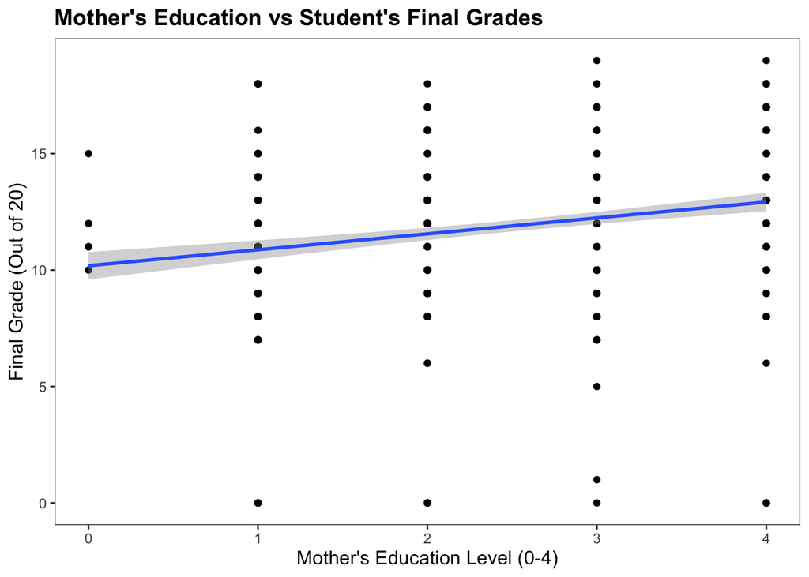

```r
ggplot(student_por, aes(Medu, G3)) +geom_point() + geom_smooth(method="lm") + xlab("Mother's Education Level (0-4)") + ylab("Final Grade (Out of 20)") +ggtitle("Mother's Education vs Student's Final Grades") + theme_apa()
```

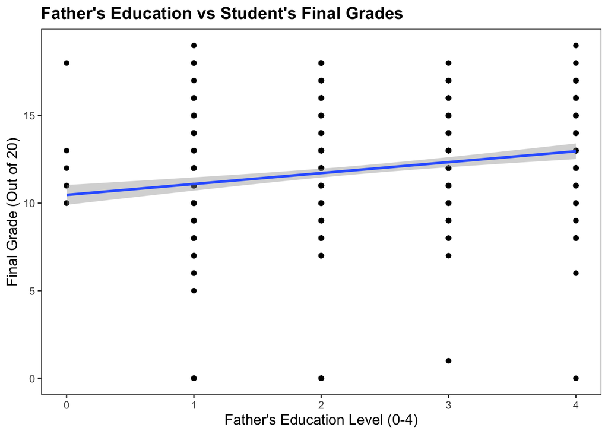

```r
ggplot(student_por, aes(Fedu, G3)) +geom_point() + geom_smooth(method="lm") + xlab("Father's Education Level (0-4)") + ylab("Final Grade (Out of 20)") +ggtitle("Father's Education vs Student's Final Grades") + theme_apa()
```

###Research Question 2:

#Hypothesis: There is a negative correlation between number of alcoholic beverages consumed during the weekdays and students grades.

```r
cor.test(student_por$Dalc, student_por$G3, alternative="less")
```

```
##
##  Pearson's product-moment correlation
##
## data:  student_por$Dalc and student_por$G3
## t = -5.32, df = 647, p-value = 7.16e-08
## alternative hypothesis: true correlation is less than 0
## 95 percent confidence interval:
##  -1.000000 -0.141972
## sample estimates:
##        cor
## -0.2047194
```

```r
#Correlation = -0.20
  #r(647)=-5.32, p<0.001
  #Weak and negative correlation. Can reject null hypothesis and say there is statistical evidence that true correlation of not equal to 0. 95% confident that true correlation value lands within the range of [-1.0, -0.14].
```

Graphing this correlation.

[figure not shown]

```r
ggplot(student_por, aes(Dalc, G3)) +geom_point() +geom_smooth(method="lm") +xlab("Weekday Alcohol Consumption ('Very Low(1)' to 'Very High(4)')") +ylab("Students' Final Grades (Out of 20)") + ggtitle("Student Weekday Alcohol Consumption vs. Students' Final Grades") + theme_apa()
```

###Research Question 3 #Hypothesis: There will be statistical differences in final grades between the students who study less the median hours studied, those who were at the median hours studied, and those who studied higher than the median hours studied. More study hours will correlate positively with higher test grades between the three groups.

```r
#First, had to subset the student_por dataset into three different groups based on how they responded in relation to the median (median=2): those who reported studying below the median, those who reported at the median, and those who reported studying above the median. Then, ran independent sample t.tests to determine if groups have significant differences in true mean differences in scores.

median(student_por$studytime)
```

```
## [1] 2
```

```r
StudyBelowMedian <- student_por %>% filter(studytime<2)
StudyAtMedian <- student_por %>% filter(studytime==2)
StudyAboveMedian <- student_por %>% filter(studytime>2)


cor.test(student_por$studytime, student_por$G3)
```

```
##
##  Pearson's product-moment correlation
##
## data:  student_por$studytime and student_por$G3
## t = 6.5617, df = 647, p-value = 1.091e-10
## alternative hypothesis: true correlation is not equal to 0
## 95 percent confidence interval:
##  0.176215 0.320587
## sample estimates:
##       cor
## 0.2497887
```

```r
  #Correlational test shows that there is a statistically significant correlation (differing from 0) within our data, t(647)=6.5617, p<0.001. We have a positive but weak correlation between student study time and student final grade.

t.test(StudyAtMedian$G3, StudyBelowMedian$G3, var.equal=FALSE, alternative="greater")
```

```
##
##  Welch Two Sample t-test
##
## data:  StudyAtMedian$G3 and StudyBelowMedian$G3
## t = 4.3209, df = 456.2, p-value = 9.544e-06
## alternative hypothesis: true difference in means is greater than 0
## 95 percent confidence interval:
##  0.77162     Inf
## sample estimates:
## mean of x mean of y
##  12.09180  10.84434
```